# Framing and identity

# Framing

## Framing

> …schemata of interpetation [that enable individuals] to locate, perceive, identify and label experiences

> — Irving Goffman (1974)

Examples:

- Selective emphasis/de-emphasis of certain facts
- Arguments that justify action or inaction
- Attributions/denials of responsibility

## Politicizing the personal

[figure not shown]

1952 Ad for Ingles automatic washer

[figure not shown]

Flyer from the International Wages for Housework Campaign

## Core framing tasks

- Diagnostic
- Prognostic
- Motivational

### Diagnostic

What is the problem, and who is at fault?

- Who is to blame for climate change?
- Is it a systemic problem or a problem of individual over-consumption?
- How does it relate to other issues like global inequality?

[figure not shown]

### Prognostic

What, if anything, should be done about the problem?

- MADD emerged at a time when drunk driving was often addressed alongside other public health problems associated with alcohol use.
- MADD successfully persuaded politicians to address it as a criminal justice issue.

[figure not shown]

### Motivational

Who should act and why?

- “Pity” and “charity” frames can be effective ways to mobilize donations to disability-related causes.
- But disability activists argue they undermine other goals like dignity, access, and personal autonomy.

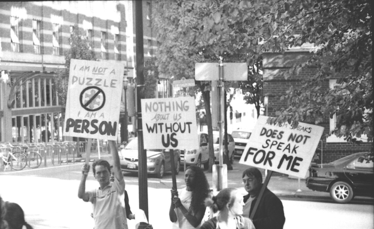

### Re-Framing white power politics

- Civil rights movement established a general norm against expressions of overt racism or support for white supremacy.
- Post 1980s white supremacist activists attempt to mirror civil rights/human rights discourse rather than challenging it explicitly.
- This re-framing allowed activists like David Duke to maintain a foothold in American politics even as the Klan itself became stigmatized.

> a person like me speaks up and says, “Look, I’m interested in white rights”… he’s going to be totally ripped to shreds…. But if a person gets up and says, “Well, I’m concerned about preserving Jewish culture”… then nothing happens. — David Duke (former Klan leader)

## Some empirical research on framing

### Homeless mobilization: Cress and Snow (2000)

Cress and Snow (2000)

- How does framing impact the success/failure of homeless advocacy groups?
- Uses a set of in-depth interviews/data collection on 15 homeless advocacy groups.

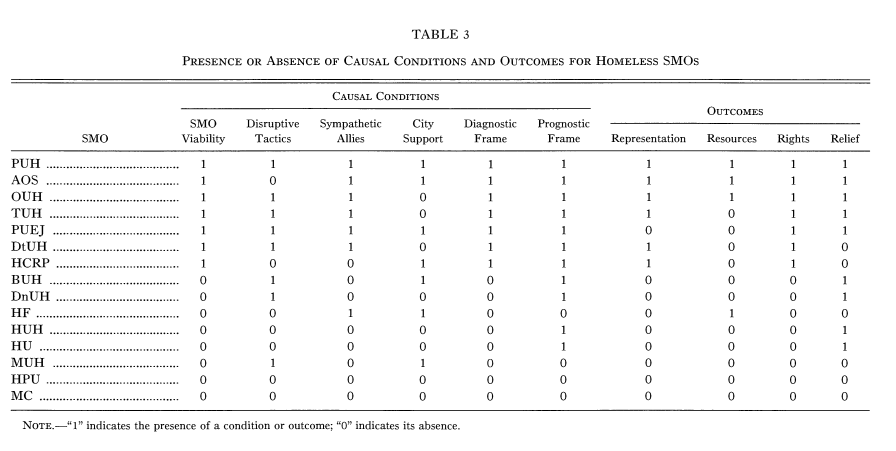

### Homeless mobilization: Cress and Snow (2000)

- Authors use qualitative-comparative analysis to identify what they say are “necessary/sufficient” conditions for success.
- Findings suggest diagnostic/prognostic framing are important features alongside things like opportunity structure and resources.

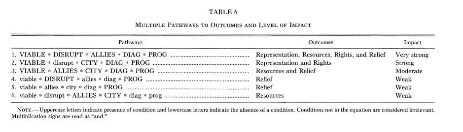

### Framing human rights appeals: McEntire, Leiby and Krain (2015)

McEntire, Leiby, and Krain (2015)

- What messages increase support for human rights causes? What messages increase willingness to participate?
- Survey experiment using three framing types: “Informational”, “Personal” or “Motivational”

[figure not shown]

[figure not shown]

[figure not shown]

### Framing human rights appeals: McEntire, Leiby and Krain (2015)

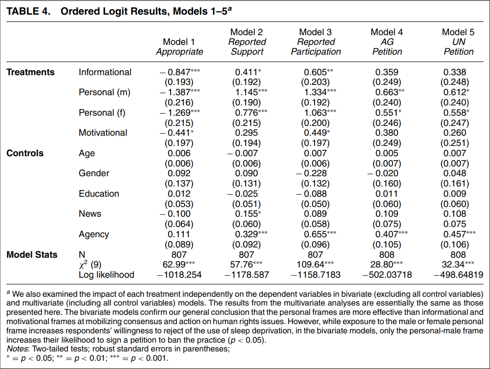

### Framing human rights appeals: McEntire, Leiby and Krain (2015)

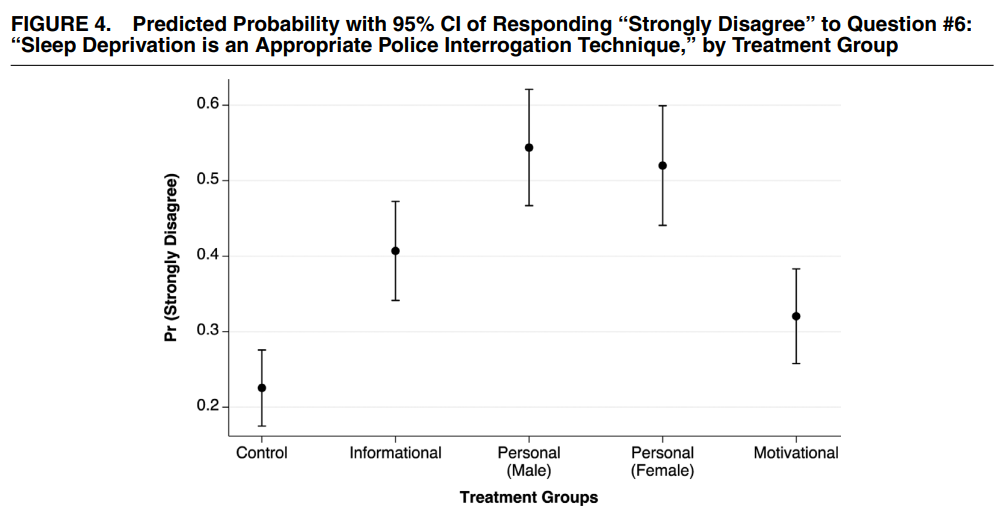

### Framing in social media texts: Mendelsohn et. al. (2024)

Mendelsohn et al. (2024)

- How do different socio-cultural groups frame issues on social media?
- Authors use text analysis on twitter social media posts from 2018-2019 to identify frames that are more or less common for differetn causes/levels of activity/or types of tweet.

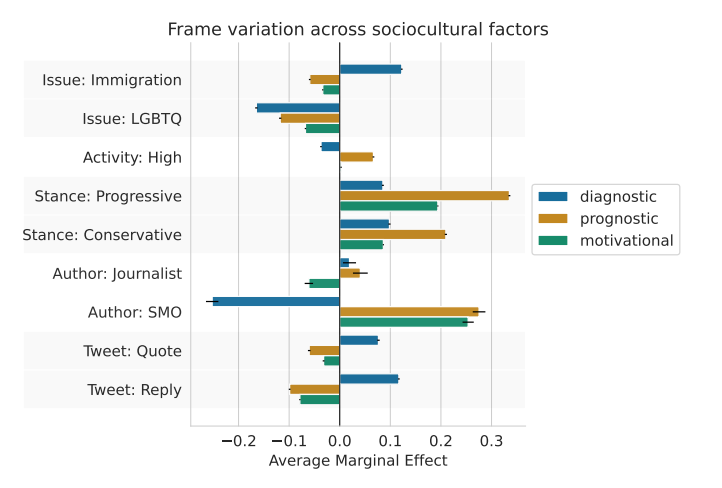

# Identity

## Identity and interests

- “Collective interests” play a key role in most accounts of contention, but this depends on a self concept.
- Identities are constructed, overlapping, and may become salient (or not) depending on the scenario.

## Tajfel and Turner: Self categorization

[figure not shown]

- In a series of experiments, Henri Tafjel and John Turner attempted to foment inter-group conflict on the basis of essentially meaningless distinctions.

## Tajfel and Turner: Self categorization

[figure not shown]

Social identity theory: - Social Categorization: who are we? - Social comparison: How are we doing relative to other groups? - Social Identity: Desire for positive distinctiveness leads to either assimilation or collective action

## Early gay rights movements

- Early gay rights activism often promoted assimilation and downplayed the importance of sexual orientation.
- The emergence of the psychiatric model of “homosexuality” made it a fixed characteristic.
- The “Lavender Scare” portrayed many gay people as intrinsically untrustworthy.

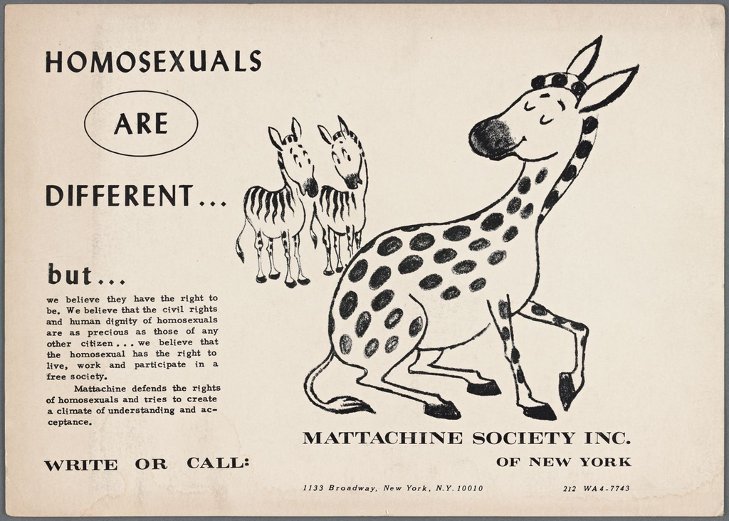

Flyer for the Mattachine Society (founded in 1950)

## Modern gay rights movements

- Without the ability to assimilate out of a stigmatized identity, many gay activists shifted their energy towards promoting a positive self-identity.

[figure not shown]

## Questions

- When/how does identity become salient?
- Does identity trump material interests?
- Can we make meaningful predictions about the role of identity in contentious politics in general?

## Citations

[figure not shown]

Cress, Daniel M, and David A Snow. 2000. “The Outcomes of Homeless Mobilization: The Influence of Organization, Disruption, Political Mediation, and Framing.” *American Journal of Sociology* 105 (4): 1063–1104.

McEntire, Kyla Jo, Michele Leiby, and Matthew Krain. 2015. “Human Rights Organizations as Agents of Change: An Experimental Examination of Framing and Micromobilization.” *American Political Science Review* 109 (3): 407–26.

Mendelsohn, Julia, Maya Vijan, Dallas Card, and Ceren Budak. 2024. “Framing Social Movements on Social Media: Unpacking Diagnostic, Prognostic, and Motivational Strategies.” *arXiv Preprint arXiv:2406.13820*.